# Source memory performance for objects outside the rooms

# 1 Visual inspection of the data

# 2 Novelty Benefits

## 2.1 Check the data

**Is there any corrected hit rate < 0?**

There are 15 negative value out of a total of 80 participants.

```
##     SubjectNo    Group MeanCurRt  MeanDur     SFHit      SHit     SrcHit
##  1:       P18    Novel  5.666667      NaN 0.5555556 0.1666667 0.11111111
##  2:       P22    Novel  6.000000      NaN 0.4166667 0.1666667 0.08333333
##  3:       P23    Novel  5.666667      NaN 0.7777778 0.6666667 0.11111111
##  4:       P24    Novel  6.333333      NaN 0.3888889 0.2222222 0.05555556
##  5:       P26 Familiar  2.000000      NaN 0.7777778 0.3333333 0.11111111
##  6:       P31    Novel  6.000000      NaN 0.1111111 0.0000000 0.00000000
##  7:       P34 Familiar  2.666667      NaN 0.5555556 0.0000000 0.05555556
##  8:       P36 Familiar  5.000000      NaN 0.3888889 0.1666667 0.11111111
##  9:       P45 Familiar  4.666667 30.43362 0.7222222 0.3888889 0.00000000
## 10:       P46    Novel  6.000000 27.90698 0.6666667 0.6111111 0.11111111
## 11:       P49 Familiar  4.000000 25.81284 0.5555556 0.2777778 0.05555556
## 12:       P52 Familiar  1.500000 48.01050 0.5833333 0.3333333 0.08333333
## 13:       P52    Novel  5.500000 49.26337 0.7500000 0.5000000 0.08333333
## 14:       P53    Novel  5.333333 23.68109 0.3333333 0.0000000 0.00000000
```

[output cut: 17 more lines]

## 2.2 Compare mean accuracy between *novel* and *familiar* rooms

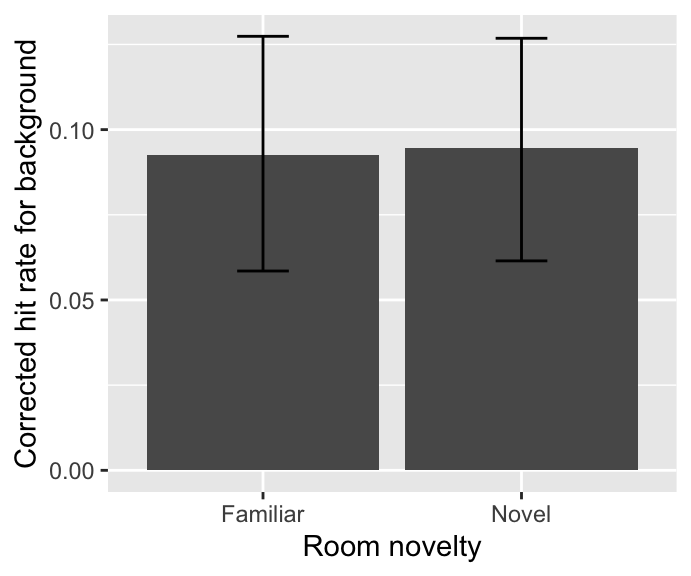

Figure1. Mean accuracy for item memory respectively for Familiar and Novel rooms.

```
##       Group       Mean        SD  N
## 1:    Novel 0.09453704 0.1095450 40
## 2: Familiar 0.09245370 0.1160234 40
```

```
##
##  Paired t-test
##
## data:  SrcAcc by Group
## t = -0.08961, df = 39, p-value = 0.9291
## alternative hypothesis: true difference in means is not equal to 0
## 95 percent confidence interval:
##  -0.04910847  0.04494181
## sample estimates:
## mean of the differences
##            -0.002083333
```

## 2.3 Any difference between *Early* and *Later* object groups?

**Is there any corrected hit rate < 0?**

There are 41 negative values out of a total of 160 participants.

```
##     SubjectNo    Group ObjOrdGrp MeanCurRt  MeanDur     SFHit      SHit
##  1:       P18 Familiar     Early  3.333333      NaN 0.5555556 0.3333333
##  2:       P18    Novel     Later  5.666667      NaN 0.4444444 0.1111111
##  3:       P19 Familiar     Early  3.333333      NaN 0.5555556 0.2222222
##  4:       P19    Novel     Later  6.333333      NaN 0.5555556 0.4444444
##  5:       P20 Familiar     Early  4.666667      NaN 0.2222222 0.2222222
##  6:       P22    Novel     Early  6.000000      NaN 0.1666667 0.0000000
##  7:       P22 Familiar     Later  2.500000      NaN 0.1666667 0.0000000
##  8:       P23 Familiar     Later  5.000000      NaN 0.4444444 0.2222222
##  9:       P23    Novel     Later  5.666667      NaN 0.6666667 0.4444444
## 10:       P24    Novel     Early  6.333333      NaN 0.5555556 0.2222222
## 11:       P26 Familiar     Later  2.000000      NaN 0.8888889 0.4444444
## 12:       P26 Familiar     Early  2.000000      NaN 0.6666667 0.2222222
## 13:       P28    Novel     Later  6.333333      NaN 0.1111111 0.1111111
## 14:       P30 Familiar     Early  4.666667      NaN 0.3333333 0.2222222
```

[output cut: 114 more lines]

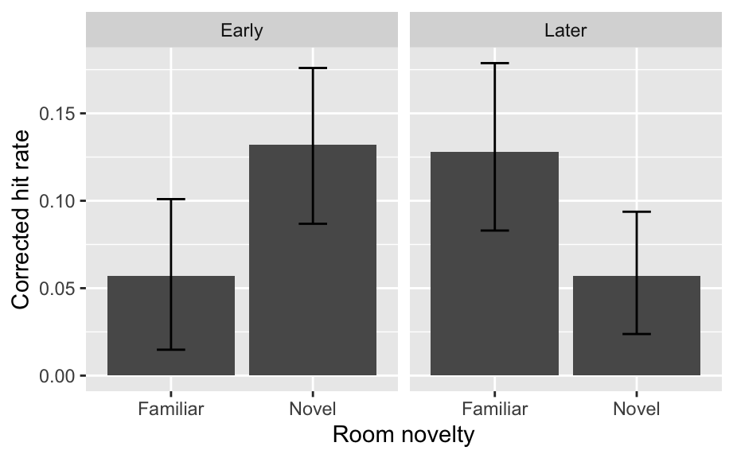

### 2.3.1 Repeated-measure ANOVA

```
##       Group ObjOrdGrp       Mean        SD  N
## 1:    Novel     Early 0.13203704 0.1535221 40
## 2: Familiar     Later 0.12787037 0.1519942 40
## 3:    Novel     Later 0.05703704 0.1173458 40
## 4: Familiar     Early 0.05703704 0.1401693 40
```

```
## $ANOVA
##            Effect DFn DFd            F            p p<.05          ges
## 2           Group   1  39  0.008030015 0.9290554819       5.557985e-05
## 3       ObjOrdGrp   1  39  0.012889721 0.9101905129       5.557985e-05
## 4 Group:ObjOrdGrp   1  39 13.548920750 0.0007017111     * 6.374852e-02
```

#### 2.3.1.1 *Post-hoc*

##### 2.3.1.1.1 Early

```
##
##  Paired t-test
##
## data:  SrcAcc by Group
## t = -2.1858, df = 39, p-value = 0.0349
## alternative hypothesis: true difference in means is not equal to 0
## 95 percent confidence interval:
##  -0.14440483 -0.00559517
## sample estimates:
## mean of the differences
##                  -0.075
```

##### 2.3.1.1.2 Later

```
##
##  Paired t-test
##
## data:  SrcAcc by Group
## t = 2.6996, df = 39, p-value = 0.01021
## alternative hypothesis: true difference in means is not equal to 0
## 95 percent confidence interval:
##  0.01776093 0.12390574
## sample estimates:
## mean of the differences
##              0.07083333
```

# 3 Curiosity Enhancement

## 3.1 Check the data

### 3.1.1 Is there any corrected hit rate < 0?

#### 3.1.1.1 For the data per room

- There are 69 negative values out of a total of 236 values.

```
##     SubjectNo     Context    Group CurRating RoomOrder Duration     SFHit
##  1:       P14 StorageRoom    Novel         6     First       NA 0.8333333
##  2:       P15     Library    Novel         7    Second       NA 0.6666667
##  3:       P18   Classroom Familiar         5    Second       NA 0.3333333
##  4:       P18  LivingRoom    Novel         7     First       NA 0.3333333
##  5:       P19         Gym Familiar         3    Second       NA 0.8333333
##  6:       P20   Classroom Familiar         4     First       NA 0.0000000
##  7:       P20     Library    Novel         2     First       NA 0.0000000
##  8:       P20 StorageRoom    Novel         6    Second       NA 0.1666667
##  9:       P22   Classroom    Novel         7    Second       NA 0.1666667
## 10:       P23   Classroom    Novel         5     First       NA 0.6666667
## 11:       P24     Bedroom    Novel         6    Second       NA 0.1666667
## 12:       P24   Classroom    Novel         6    Second       NA 0.3333333
## 13:       P24 StorageRoom Familiar         3    Second       NA 0.0000000
## 14:       P26         Gym    Novel         6     First       NA 0.8333333
```

[output cut: 198 more lines]

#### 3.1.1.2 For the data per curiosity group

- There are 15 negative value for curiosity group (1 ~ 3 and 5 ~ 7) out of a total of 76 values.

```
##     SubjectNo CurGrp  MeanDur     SFHit       SHit     SrcHit   SFFalse
##  1:       P18   High      NaN 0.4444444 0.05555556 0.05555556 0.3888889
##  2:       P22   High      NaN 0.4166667 0.16666667 0.08333333 0.2222222
##  3:       P23   High      NaN 0.8333333 0.66666667 0.12500000 0.5000000
##  4:       P24   High      NaN 0.3888889 0.22222222 0.05555556 0.3333333
##  5:       P26    Low      NaN 0.7777778 0.33333333 0.11111111 0.3333333
##  6:       P31   High      NaN 0.1111111 0.00000000 0.00000000 0.2222222
##  7:       P34    Low      NaN 0.5555556 0.00000000 0.05555556 0.4444444
##  8:       P36   High      NaN 0.5416667 0.33333333 0.08333333 0.5000000
##  9:       P46   High 27.90698 0.6666667 0.61111111 0.11111111 0.5555556
## 10:       P48    Low 30.43891 0.8333333 0.58333333 0.00000000 0.5000000
## 11:       P49    Low 29.26988 0.5000000 0.33333333 0.00000000 0.3333333
## 12:       P52    Low 48.01050 0.5833333 0.33333333 0.08333333 0.4000000
## 13:       P52   High 49.26337 0.7500000 0.50000000 0.08333333 0.4000000
## 14:       P53   High 23.68109 0.3333333 0.00000000 0.00000000 0.2222222
```

[output cut: 17 more lines]

#### 3.1.1.3 For the data per curiosity group (median)

- There are 15 negative value for curiosity group (median) out of a total of 79 values.

```
##     SubjectNo CurGrpMedian  MeanDur     SFHit       SHit     SrcHit
##  1:       P18         High      NaN 0.4444444 0.05555556 0.05555556
##  2:       P22         High      NaN 0.4166667 0.16666667 0.08333333
##  3:       P23          Low      NaN 0.5555556 0.44444444 0.11111111
##  4:       P24         High      NaN 0.3888889 0.22222222 0.05555556
##  5:       P26          Low      NaN 0.7777778 0.33333333 0.11111111
##  6:       P30          Low      NaN 0.2500000 0.08333333 0.08333333
##  7:       P31         High      NaN 0.1111111 0.00000000 0.00000000
##  8:       P34          Low      NaN 0.5555556 0.00000000 0.05555556
##  9:       P36         High      NaN 0.6111111 0.38888889 0.05555556
## 10:       P46         High 27.90698 0.6666667 0.61111111 0.11111111
## 11:       P49          Low 25.81284 0.5555556 0.27777778 0.05555556
## 12:       P52          Low 48.01050 0.5833333 0.33333333 0.08333333
## 13:       P52         High 49.26337 0.7500000 0.50000000 0.08333333
## 14:       P53         High 23.68109 0.3333333 0.00000000 0.00000000
```

[output cut: 17 more lines]

## 3.2 Mean accuracy of item memory as a function of curiosity rating

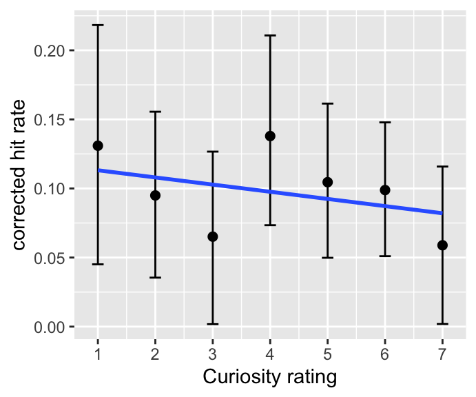

## 3.3 Testing the relationship between mean accuracy of item memory and curiosity rating

Build models with item memory accuracy as $y$ and examine effects of curiosity rating by including it into the model and then comparing the model fits.

- `baseline.rating` is the model with only an intercept, showing no change in item memory as a function of curiosity rating.
- `rating.intercept` is the model with $\small CuriosityRating$ included, showing the effects of curiosity rating.
- `rating.slope` is the model allowing the slope (i.e., relationship between item memory and curiosity rating) varying across participants.

```
##                  Model df       AIC       BIC   logLik   Test   L.Ratio
## baseline.rating      1  3 -128.6655 -118.2740 67.33275
## rating.intercept     2  4 -127.3254 -113.4701 67.66270 1 vs 2 0.6599018
## rating.slope         3  6 -123.3240 -102.5410 67.66198 2 vs 3 0.0014402
##                  p-value
## baseline.rating
## rating.intercept  0.4166
## rating.slope      0.9993
```

## 3.4 Check the curiosity groups

### 3.4.1 Separate the groups according to the rating

- *High*: curiosity rating > 4
- *Low*: curiosity rating < 4
- For curiosity rating = 4, discarded

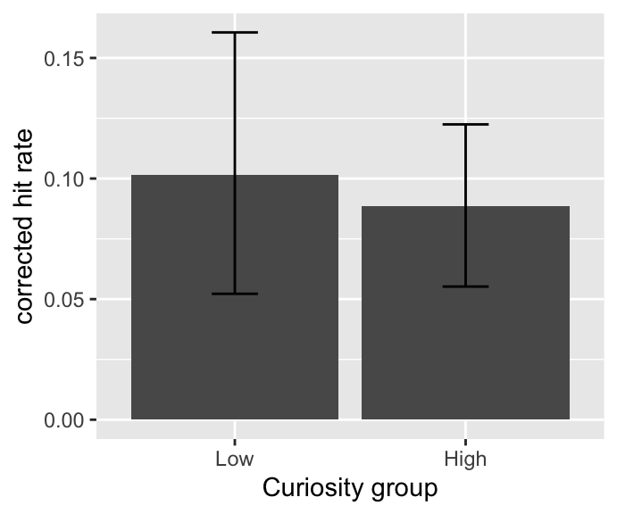

```
##    CurGrp       Mean       SD  N
## 1:   High 0.08849537 0.114223 40
## 2:    Low 0.10144033 0.163399 36
```

```
## Linear mixed-effects model fit by maximum likelihood
##  Data: outside.hit.rate.curiosity.group
##         AIC       BIC   logLik
##   -80.07474 -66.09034 46.03737
##
## Random effects:
##  Formula: ~1 + CurGrp | SubjectNo
##  Structure: General positive-definite, Log-Cholesky parametrization
##             StdDev     Corr
## (Intercept) 0.14868851 (Intr)
## CurGrpHigh  0.15305467 -0.804
## Residual    0.06145844
##
## Fixed effects: SrcAcc ~ CurGrp
##                   Value  Std.Error DF   t-value p-value
## (Intercept)  0.10031240 0.02711479 39  3.699545  0.0007
## CurGrpHigh  -0.01181703 0.02942821 35 -0.401555  0.6905
##  Correlation:
##            (Intr)
## CurGrpHigh -0.799
##
## Standardized Within-Group Residuals:
##          Min           Q1          Med           Q3          Max
## -0.898696634 -0.275629368  0.003118815  0.238339755  1.245815888
##
## Number of Observations: 76
## Number of Groups: 40
```

#### 3.4.1.1 Curiosity groups and temporal order of the objects

##### 3.4.1.1.1 Check the data

- **Is there any corrected hit rate < 0?**
  - There are 44 negative values out of a total of 152 values.

```
##     SubjectNo CurGrp ObjOrdGrp     SFHit      SHit     SrcHit   SFFalse
##  1:       P14    Low     Early 0.3333333 0.3333333 0.00000000 0.2222222
##  2:       P18    Low     Early 0.6666667 0.5000000 0.00000000 0.3888889
##  3:       P18   High     Early 0.5555556 0.1111111 0.11111111 0.3888889
##  4:       P18   High     Later 0.3333333 0.0000000 0.00000000 0.3888889
##  5:       P20    Low     Early 0.1666667 0.1666667 0.00000000 0.1111111
##  6:       P22   High     Early 0.1666667 0.0000000 0.00000000 0.2222222
##  7:       P22    Low     Later 0.1666667 0.0000000 0.00000000 0.2222222
##  8:       P23   High     Later 0.7500000 0.5000000 0.00000000 0.5000000
##  9:       P24    Low     Early 0.0000000 0.0000000 0.00000000 0.3333333
## 10:       P24   High     Early 0.5555556 0.2222222 0.00000000 0.3333333
## 11:       P26    Low     Later 0.8888889 0.4444444 0.11111111 0.3333333
## 12:       P26    Low     Early 0.6666667 0.2222222 0.11111111 0.3333333
## 13:       P28   High     Later 0.1111111 0.1111111 0.00000000 0.1111111
## 14:       P30   High     Early 0.3333333 0.1666667 0.08333333 0.2777778
```

[output cut: 77 more lines]

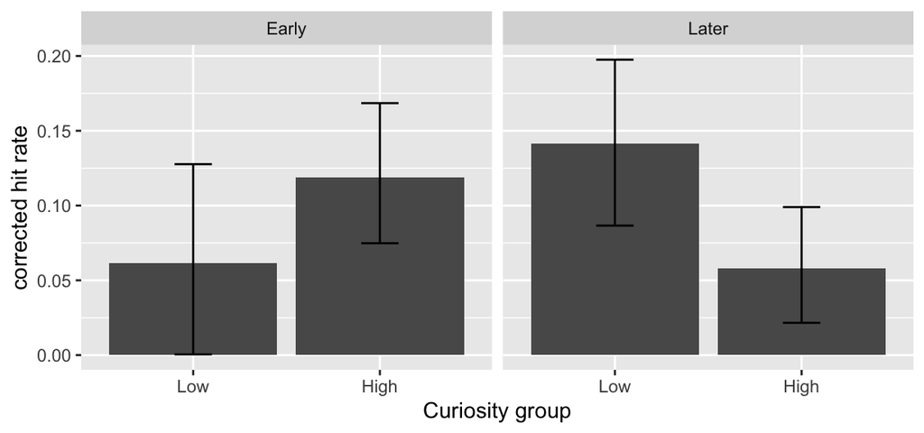

```
##    CurGrp ObjOrdGrp       Mean        SD  N
## 1:   High     Early 0.11898148 0.1547762 40
## 2:    Low     Later 0.14156379 0.1828340 36
## 3:   High     Later 0.05800926 0.1326764 40
## 4:    Low     Early 0.06131687 0.2065732 36
```

```
##           Model df        AIC       BIC   logLik   Test L.Ratio p-value
## baseline      1  8 -101.53988 -77.34883 58.76994
## ord.model     2  9  -99.60366 -72.38873 58.80183 1 vs 2 0.06378  0.8006
## cur.model     3 10  -97.76885 -67.53004 58.88442 2 vs 3 0.16519  0.6844
## int.model     4 11 -105.40437 -72.14168 63.70218 3 vs 4 9.63552  0.0019
```

```
## Linear mixed-effects model fit by maximum likelihood
##  Data: outside.hit.rate.item.order.curiosity[!is.na(CurGrp)]
##         AIC       BIC   logLik
##   -105.4044 -72.14168 63.70218
##
## Random effects:
##  Formula: ~1 + CurGrp + ObjOrdGrp | SubjectNo
##  Structure: General positive-definite, Log-Cholesky parametrization
##                StdDev      Corr
## (Intercept)    0.129214345 (Intr) CrGrpH
## CurGrpHigh     0.112328551 -0.888
## ObjOrdGrpLater 0.001985174 -0.011 -0.003
## Residual       0.135572551
##
## Fixed effects: SrcAcc ~ ObjOrdGrp + CurGrp + ObjOrdGrp:CurGrp
##                                 Value  Std.Error  DF   t-value p-value
## (Intercept)                0.06019092 0.03158198 109  1.905863  0.0593
## ObjOrdGrpLater             0.08024721 0.03238543 109  2.477880  0.0148
## CurGrpHigh                 0.05879056 0.03694071 109  1.591484  0.1144
## ObjOrdGrpLater:CurGrpHigh -0.14121943 0.04463797 109 -3.163661  0.0020
##  Correlation:
##                           (Intr) ObjOGL CrGrpH
## ObjOrdGrpLater            -0.513
## CurGrpHigh                -0.771  0.438
## ObjOrdGrpLater:CurGrpHigh  0.372 -0.725 -0.604
##
## Standardized Within-Group Residuals:
##         Min          Q1         Med          Q3         Max
## -1.66717488 -0.72387362 -0.02763188  0.56747951  2.44935603
##
## Number of Observations: 152
## Number of Groups: 40
```

##### 3.4.1.1.2 *Post hoc*

```
##
##   Simultaneous Tests for General Linear Hypotheses
##
## Fit: lme.formula(fixed = SrcAcc ~ ObjOrdGrp + CurGrp + ObjOrdGrp:CurGrp,
##     data = outside.hit.rate.item.order.curiosity[!is.na(CurGrp)],
##     random = ~1 + CurGrp + ObjOrdGrp | SubjectNo, method = "ML",
##     na.action = na.exclude, control = list(msMaxIter = 500, opt = "optim",
##         msVerbose = FALSE))
##
## Linear Hypotheses:
##                          Estimate Std. Error z value Pr(>|z|)
## Early: High vs. Low == 0  0.05879    0.03645   1.613   0.1068
## Late:  High vs. Low == 0 -0.08243    0.03645  -2.261   0.0237 *
## ---
## Signif. codes:  0 '***' 0.001 '**' 0.01 '*' 0.05 '.' 0.1 ' ' 1
## (Adjusted p values reported -- none method)
```

### 3.4.2 Separate the groups according to the median rating of each participant

- *High*: curiosity rating > median of the participant
- *Low*: curiosity rating < median of the participant

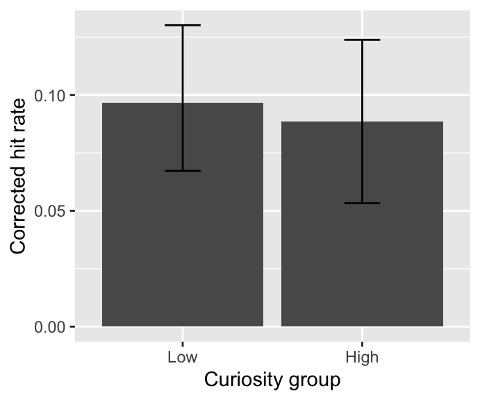

```
## Linear mixed-effects model fit by maximum likelihood
##  Data: outside.hit.rate.curiosity.group.median
##         AIC       BIC   logLik
##   -113.8342 -99.61749 62.91709
##
## Random effects:
##  Formula: ~1 + CurGrpMedian | SubjectNo
##  Structure: General positive-definite, Log-Cholesky parametrization
##                  StdDev    Corr
## (Intercept)      0.0969648 (Intr)
## CurGrpMedianHigh 0.1236425 -0.601
## Residual         0.0477394
##
## Fixed effects: SrcAcc ~ CurGrpMedian
##                        Value  Std.Error DF   t-value p-value
## (Intercept)       0.09662037 0.01730941 39  5.581955  0.0000
## CurGrpMedianHigh -0.00847892 0.02273787 38 -0.372898  0.7113
##  Correlation:
##                  (Intr)
## CurGrpMedianHigh -0.618
##
## Standardized Within-Group Residuals:
##         Min          Q1         Med          Q3         Max
## -1.01787624 -0.35022795 -0.01572018  0.24750453  1.20054496
##
## Number of Observations: 79
## Number of Groups: 40
```

#### 3.4.2.1 Curiosity groups and temporal order of the objects

##### 3.4.2.1.1 Check the data

- **Is there any corrected hit rate < 0?**
  - There are 43 negative values out of a total of 158 participants.

```
##     SubjectNo CurGrpMedian ObjOrdGrp     SFHit      SHit    SrcHit
##  1:       P18          Low     Early 0.6666667 0.4444444 0.1111111
##  2:       P18         High     Early 0.5555556 0.1111111 0.1111111
##  3:       P18         High     Later 0.3333333 0.0000000 0.0000000
##  4:       P19          Low     Early 0.5555556 0.2222222 0.1111111
##  5:       P19         High     Later 0.5555556 0.4444444 0.1111111
##  6:       P20          Low     Early 0.1111111 0.1111111 0.0000000
##  7:       P22         High     Early 0.1666667 0.0000000 0.0000000
##  8:       P22          Low     Later 0.1666667 0.0000000 0.0000000
##  9:       P23          Low     Later 0.2222222 0.1111111 0.1111111
## 10:       P23         High     Later 0.8888889 0.5555556 0.0000000
## 11:       P23          Low     Early 0.8888889 0.7777778 0.1111111
## 12:       P24         High     Early 0.5555556 0.2222222 0.0000000
## 13:       P26          Low     Later 0.8888889 0.4444444 0.1111111
## 14:       P26          Low     Early 0.6666667 0.2222222 0.1111111
```

[output cut: 75 more lines]

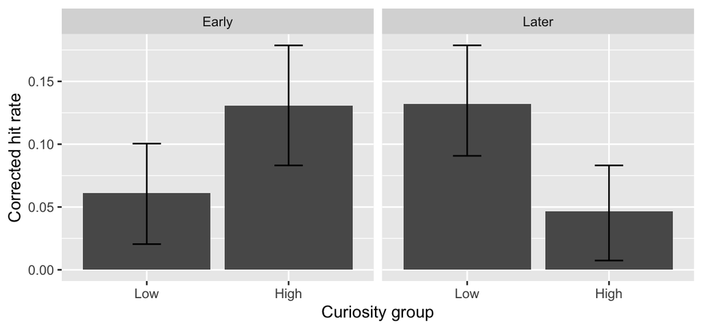

```
##    CurGrpMedian ObjOrdGrp       Mean        SD  N
## 1:         High     Early 0.13067426 0.1571898 39
## 2:          Low     Later 0.13203704 0.1462354 40
## 3:         High     Later 0.04662868 0.1181638 39
## 4:          Low     Early 0.06120370 0.1293892 40
```

```
##           Model df       AIC       BIC   logLik   Test   L.Ratio p-value
## baseline      1  8 -157.0247 -132.5240 86.51235
## ord.model     2  9 -155.0701 -127.5068 86.53507 1 vs 2  0.045433  0.8312
## cur.model     3 10 -153.2520 -122.6260 86.62600 2 vs 3  0.181849  0.6698
## int.model     4 11 -168.1649 -134.4764 95.08245 3 vs 4 16.912915  <.0001
```

```
## Linear mixed-effects model fit by maximum likelihood
##  Data: outside.hit.rate.item.order.curiosity.median[!is.na(CurGrpMedian)]
##        AIC      BIC logLik
##   -153.252 -122.626 86.626
##
## Random effects:
##  Formula: ~1 + CurGrpMedian + ObjOrdGrp | SubjectNo
##  Structure: General positive-definite, Log-Cholesky parametrization
##                  StdDev     Corr
## (Intercept)      0.05181102 (Intr) CrGrMH
## CurGrpMedianHigh 0.06673293 -0.334
## ObjOrdGrpLater   0.02859436  0.751 -0.739
## Residual         0.12506782
##
## Fixed effects: SrcAcc ~ ObjOrdGrp + CurGrpMedian
##                        Value  Std.Error  DF   t-value p-value
## (Intercept)       0.09949660 0.01920045 116  5.181992  0.0000
## ObjOrdGrpLater   -0.00575247 0.02060575 116 -0.279168  0.7806
## CurGrpMedianHigh -0.00848503 0.02280469 116 -0.372074  0.7105
##  Correlation:
##                  (Intr) ObjOGL
## ObjOrdGrpLater   -0.439
## CurGrpMedianHigh -0.522 -0.077
##
## Standardized Within-Group Residuals:
##        Min         Q1        Med         Q3        Max
## -1.8895806 -0.6537983 -0.0756583  0.5793537  2.3788249
##
## Number of Observations: 158
## Number of Groups: 40
```

##### 3.4.2.1.2 *Post hoc*

```
##
##   Simultaneous Tests for General Linear Hypotheses
##
## Fit: lme.formula(fixed = SrcAcc ~ ObjOrdGrp + CurGrpMedian + ObjOrdGrp:CurGrpMedian,
##     data = outside.hit.rate.item.order.curiosity.median[!is.na(CurGrpMedian)],
##     random = ~1 + CurGrpMedian + ObjOrdGrp | SubjectNo, method = "ML",
##     na.action = na.exclude, control = list(msMaxIter = 500, opt = "optim",
##         msVerbose = FALSE))
##
## Linear Hypotheses:
##                          Estimate Std. Error z value Pr(>|z|)
## Early: High vs. Low == 0  0.06912    0.02867   2.411  0.01591 *
## Late:  High vs. Low == 0 -0.08617    0.02866  -3.007  0.00264 **
## ---
## Signif. codes:  0 '***' 0.001 '**' 0.01 '*' 0.05 '.' 0.1 ' ' 1
## (Adjusted p values reported -- none method)
```